# Final Project Draft

Discussion 326, Group 2

11/18/2020

# Group Members

- Yuliang Peng
- Aidan Seeberg
- Xavier Zimmerman
- Ethan Hood

# Introduction

Every song has a number of associated metadata such as its genre, year of release, BPM, and more. With data collected from a mass streaming service like Spotify, songs also have a marked popularity. Our dataset will help us find what makes a song popular among Spotify users. More specifically, we will consider each of the following:

- Which numerical aspect of a song has the strongest correlation to its popularity?
- What types of genres become the most popular?
- Which artists and types of artists have remained the most popular over the decade 2010-2019?
- Are songs with a featured artists generally more popular?

**Thesis**: While there are similarities between songs and artists that are popular at any one time, the popularity of a song is not influenced directly by any one variable.

# Background

Our dataset presents a number of Billboard’s most popular songs every year over a decade. This data was collected from Spotify’s own API, with song selection based on Billboard charts.

Variables include:

- **ID**: An arbitrary index
- **Title**: The song’s title
- **Artist**: The song’s creator
- **Genre**: A binned category for what type of song (pop, country, rap, etc…)
- **Year**: The year the song was debuted
- **BPM**: (Beats Per Minute) Tempo/how fast the song is
- **Energy**: Perceived energy of the song; the higher the value, the more energetic
- **Danceability**: Perceived danceability of the song; the higher the value, the easier it is to dance to
- **Loudness** : In decibels. How loud the song is
- **Liveness**: The higher the value, the more likely the song is a live recording
- **Valence**: The higher the value, the more positive mood for the song
- **Acousticness**: The higher the value, the more acoustic the song is
- **Speechiness**: The higher the value, the more spoken words the song contains
- **Popularity**: The higher the value, the more popular the song is
- **Duration**: Length of the song

This data can be found at [Top Spotify songs from 2010-2019 - BY YEAR from Kaggle](https://www.kaggle.com/leonardopena/top-spotify-songs-from-20102019-by-year).

While this data is fit for analysis, we consider a few unusual factors that could affect final results. Many columns are transformed to a 0-100 numerical scale; without the context of other rows, these values are arbitrary. Additionally, some values for BPM are 0 which intuitively is impossible. These values will be removed from the dataset when BPM is considered.

The rest of this report will consist of four separate analyses of possible factors that influence a songs popularity, followed by a comprehensive conclusion tying together the results.

# Question 1

### Which numerical aspect of a song has the strongest correlation to its popularity?

All of the songs in this data have different aspects that are measured numerically in the data set. We examined all of these values individually in relation to the Popularity value to see if any of these values seemed to have a corelation to Popularity.

#### Analysis

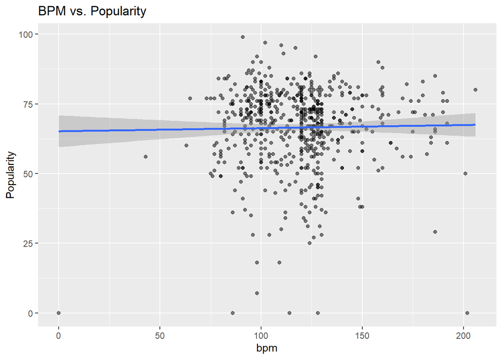

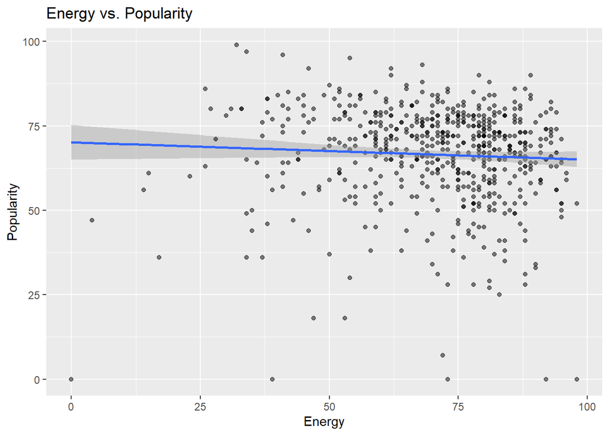

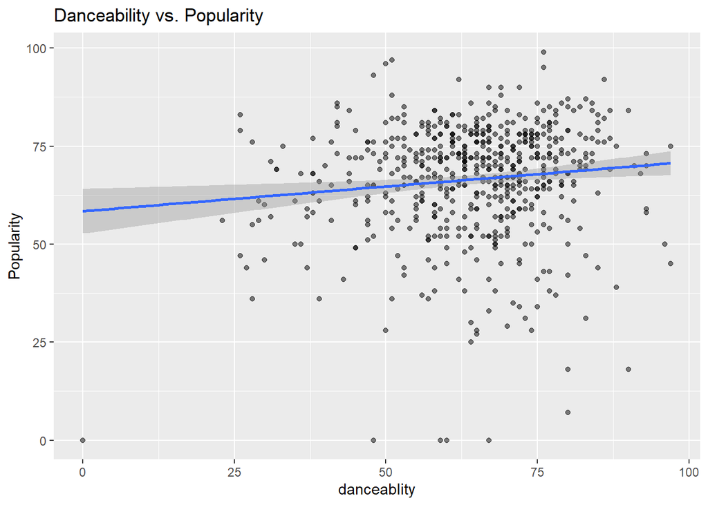

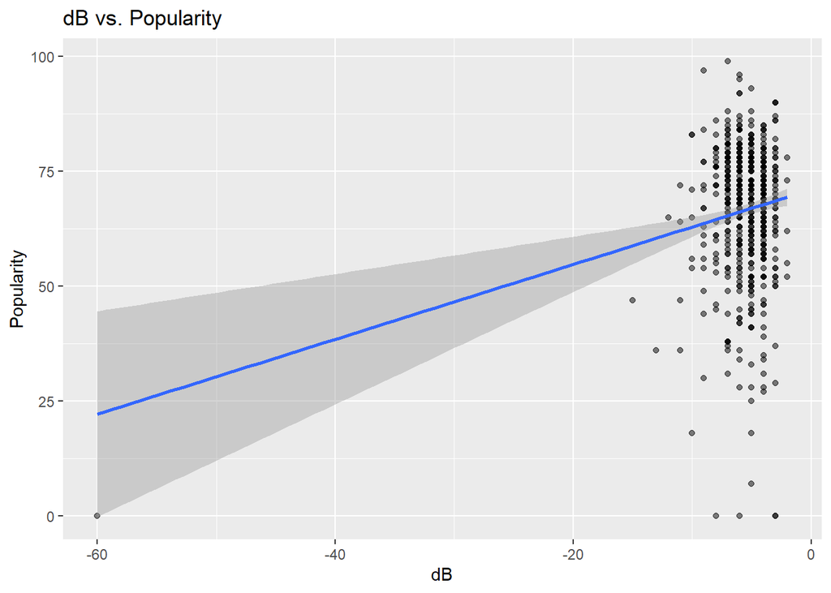

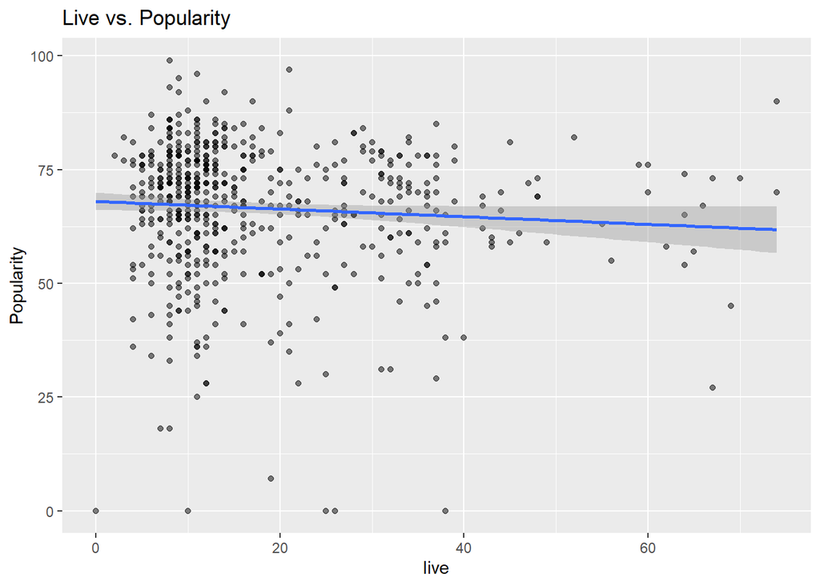

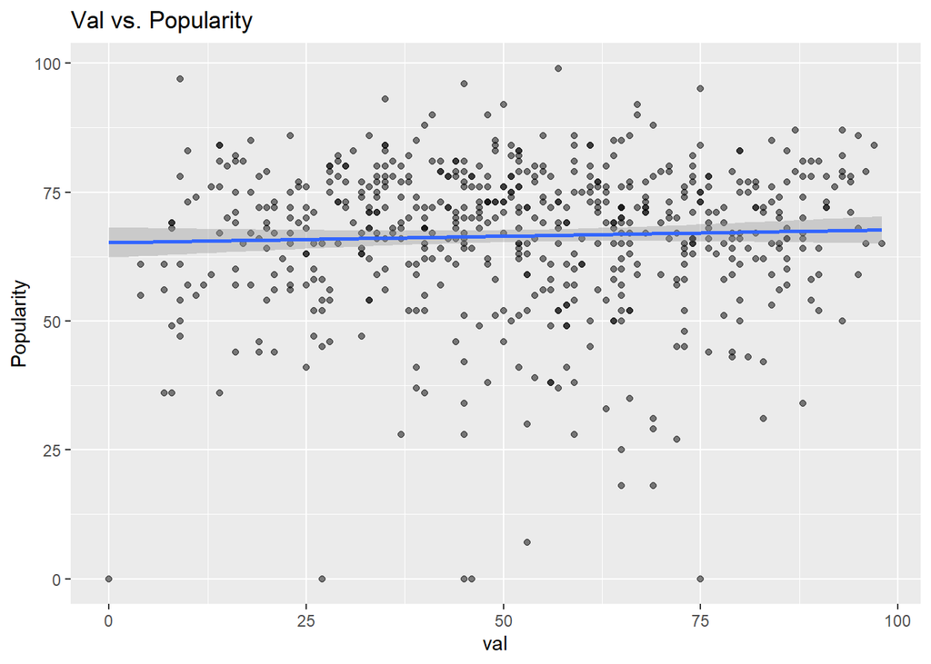

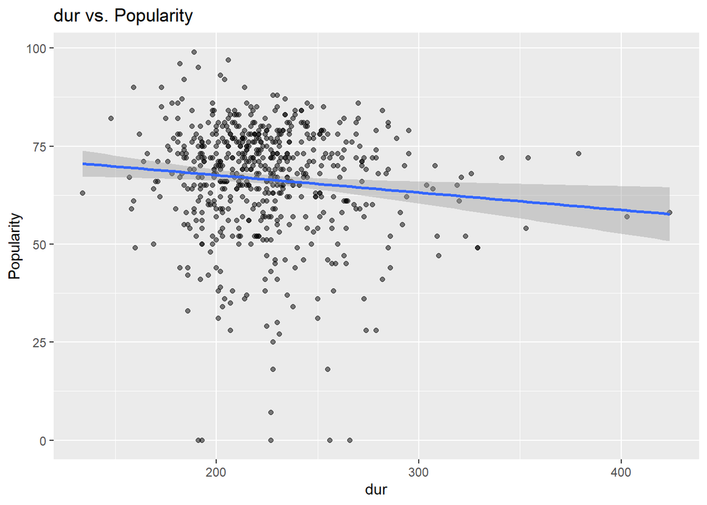

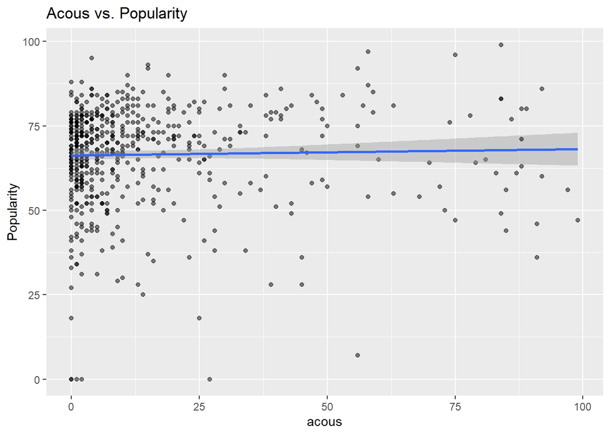

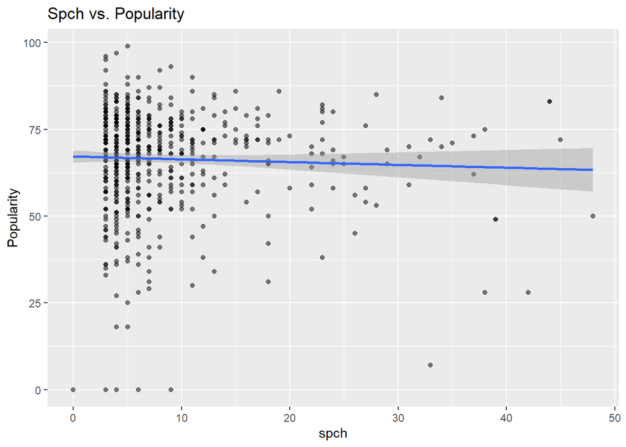

```
##    dB             title
## 1 -60 Million Years Ago
```

The graph shows a range of dB values from -60 to 0 but there is only one song with a dB value lower than -15. This song is Million Years Ago and is at a value of -60 which signigficantly skews the fit line.

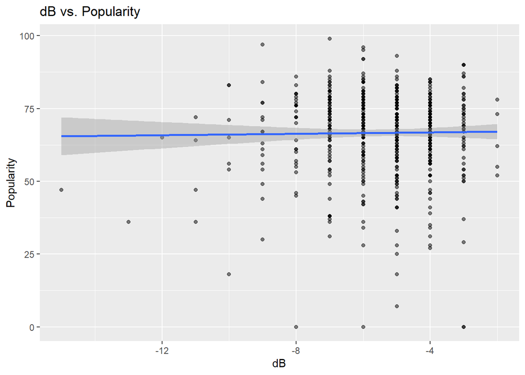

```
##       BPMcorr  Energycorr Danceabilitycorr Decibelscorr Livenesscorr
## 1 -0.01812839 -0.09369345       0.08239361   0.01440024  -0.01812839
##   Valencecorr Durationcorr Acousticcorr  Speechcorr
## 1  0.02174557   -0.1057065   0.02183701 -0.05095561
```

If this outlier is removed then the linear fit line is very close to horizontal which is consitent with the rest of the aspects. This shows that these aspects within the most popular songs do not have a strong correlation to the popularity.

If we look at the correlation between the different aspects and popularity there is never a correlation greater than .11 which is for duration. Duration has the largest correlation but none of the correlation values are significant enough to make any real claims.

# Question 2

### Does the relevance of an artist influence their songs’ popularities?

The music industry features many names, but for some, it’s hard to stay at the top. A one hit wonder is an artist who has only one popular song. In this section, we attempt to find if one hit wonders are truly more popular than recurring artists.

#### Analysis

[figure not shown]

[figure not shown]

```
## [1] 0.2825108
```

This p_value shows that the difference between popularity means is not statistically significant. Therefore, the relevance of an artist does not dictate the popularity of their song.

# Question 3

### Which artists and types of artists have remained the most popular over the decade 2010-2019?

This is a draft of STAT 240 Final Project focusing on the question: **Which artists have remained the most popular over the decade 2010-2019?**

Specific questions including:

- Do pop artists remain longer on the billboards in average?

```
## # A tibble: 2 x 2
## # Groups:   top.genre [2]
##   top.genre     n
##   <chr>     <int>
## 1 pop         485
## 2 non_pop     118
```

From the form `pop_nonpop` we can see that there are 485 songs labeled with “pop” and 118 that are not labeled “pop.” Our evaluation will be based on the difference between the artists of the 485 pop songs and the 118 non-pop songs.

```
## # A tibble: 184 x 4
## # Groups:   top.genre, artist [184]
##    top.genre artist                  n index
##    <chr>     <chr>               <int> <int>
##  1 pop       3OH!3                   1     1
##  2 non_pop   5 Seconds of Summer     1     2
##  3 non_pop   A Great Big World       1     3
##  4 pop       Adam Lambert            1     4
##  5 non_pop   Adele                   5     5
##  6 non_pop   Alan Walker             1     6
##  7 non_pop   Alessia Cara            3     7
##  8 non_pop   Alesso                  1     8
##  9 pop       Alicia Keys             4     9
## 10 pop       Ansel Elgort            1    10
## # ... with 174 more rows
```

```
## [1] 128
```

```
## [1] 56
```

The form artist_year displays artists with specific genre (pop or non-pop) and their time remaining on the board, among them, there are 128 pop artists and 56 non-pop artists. An artist with two different genre productions is considered to have two identities (he/she will be counted separately in pop and non-pop genres).

Therefore, we would like to find out the difference between pop and non-pop artists’ average year lasting on the billboard.

#### Analysis

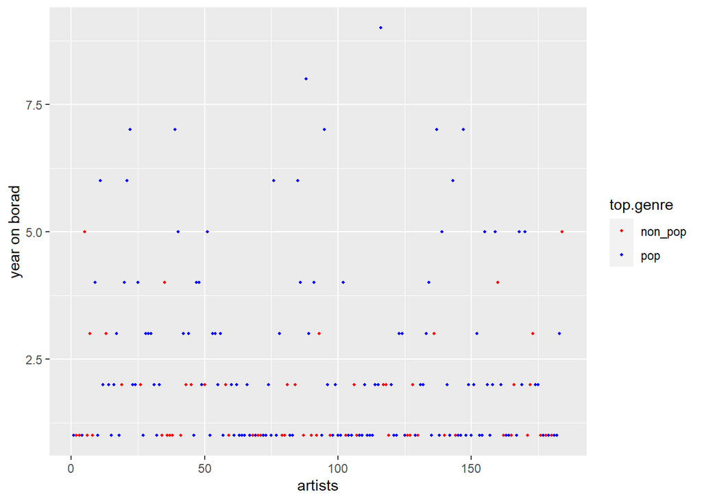

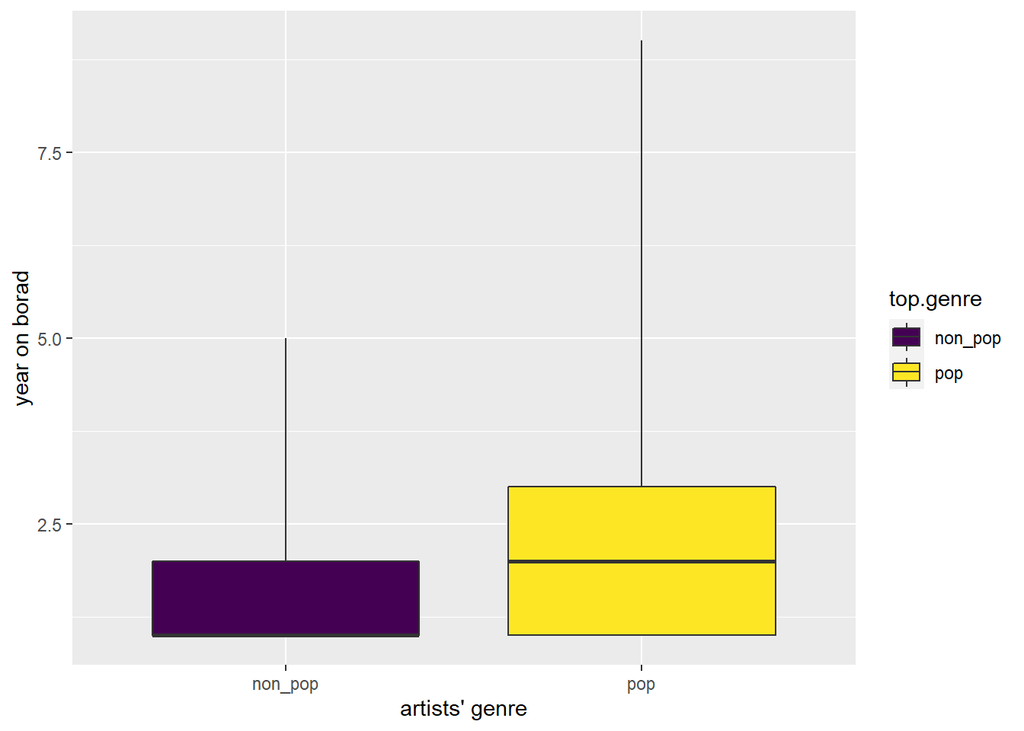

From the scatter plot we can see that only some pop artists lasted for over 5 years, and only two non-pop artists were able to remain on the board for 5 years from 2010-2019. From the boxplot we can see that the median year for pop artists is greater than that of the non-pop artists, and the year range lasted for pop artists is also wider than that of the non-pop artists.

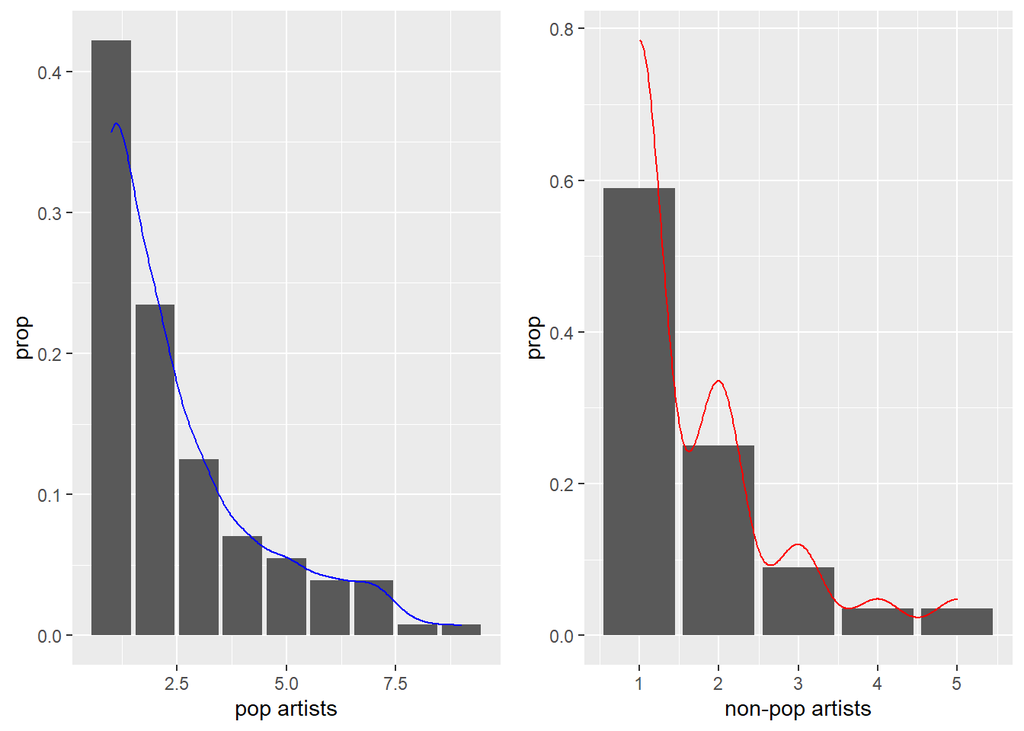

The density curves show that the distribution of pop artists’ years of lasting is likely to be an unimodel centers around 1, while the distribution of non-pop artists is more like a multimodel, but the peaks gradually lowering and range stretching for each peak, which resembles an unimodel centered around 1 in a broader view.

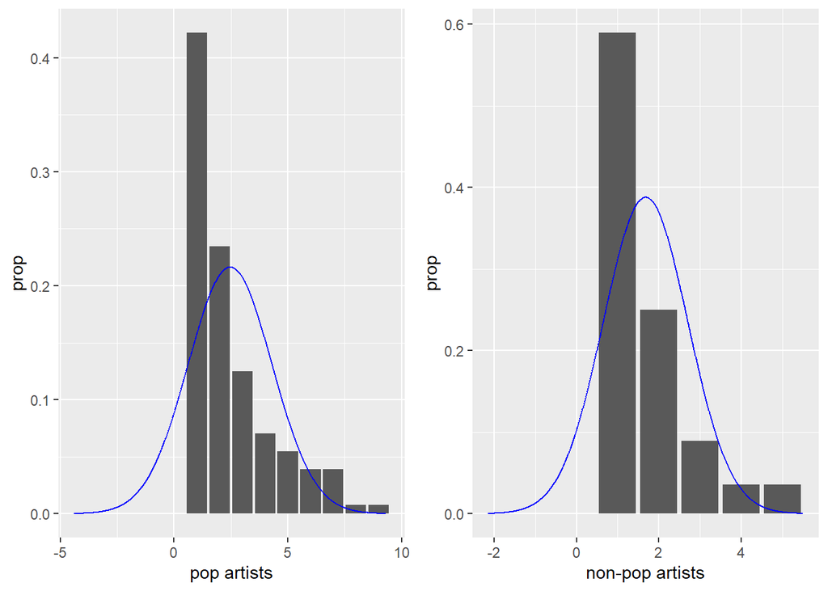

From the two bar plots with normal density curves above, we can see that the plots don’t fit very well with the normal curve, and it’s hard to simply assume that the distribution of artists’ lasting years on the billboard is normal. It can also be observed that the number of artists who are on board for only one year greatly exceeds the other artists.

In order to see whether this can be an influence factor of the distribution of the artists (since the normal curve can be extended to less than zero but the artists year on board can’t), we dropped the artists who are on board for just one year, but keep the normal distribution with the same parameters (mu and sigma).

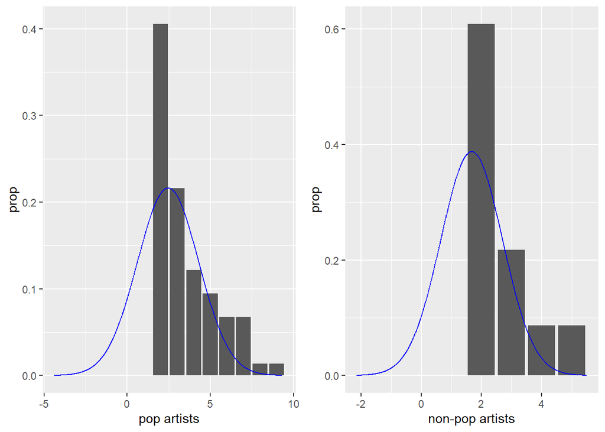

In the graphs above, the distribution of artists’ year on board appears to be close to the normal distribution (for both pop and non-pop artists). The prominently exceeding portions in pop artists (when year lasting=2) plus the proportion of pop artitss when year lasting=1 is around 0.54, which is half of the distribution, suggesting that the sample of pop artists’ year lasting on billboard may be normally distributed. However, the statistics for the same proportion in the non-pop artists is around 0.67, suggesting that the distribution of non-pop artists’ year lasting on board may not be normally distributed.

However, we will still perform an two sample t-test assuming the two populations are normally distributed.

Hypothesis:
$$H_0: \bar{x_p}=\bar{x_n}$$
$$H_a: \bar{x_p}>\bar{x_n}$$

Assumptions:

- The two samples are normally distributed.
- The samples are independent.

```
##
##  Welch Two Sample t-test
##
## data:  pop and npop
## t = 3.0014, df = 68.561, p-value = 0.001873
## alternative hypothesis: true difference in means is greater than 0
## 95 percent confidence interval:
##  0.3888423       Inf
## sample estimates:
## mean of x mean of y
##  3.527027  2.652174
```

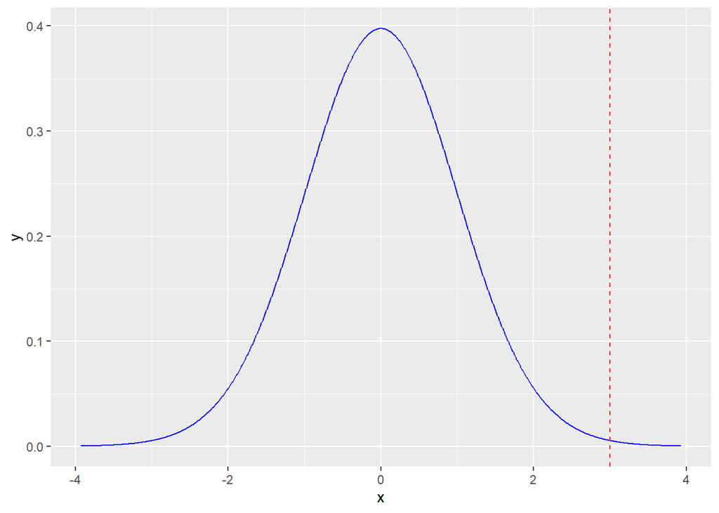

According to the test and graph above, the p value of the assumption that $\bar{x_p}=\bar{x_n}$ is far less than 0.01, we have strong evidence to reject the null hypothesis. The average lasting time for pop artists is greater than that for the non-pop artists.

However, does a longer time remaining on board guarantee a higher popularity? In the next section, we will explore the relationship between artists’ year on board and their songs’ average popularity.

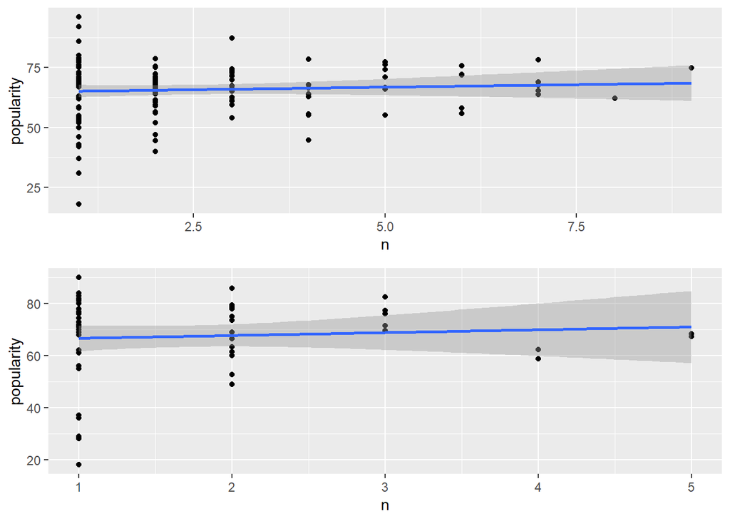

Although the songs’ average popularity tend to have some slight increase as the artists’ year on board increase, the best fit line still remains almost a horizontal line – that is, the relationship between a song’s popularity and its artist’s year on the billboard is not prominent. Therefore, we will not carry out a hypothesis test based on the shape of the graph.

# Question 4

### Are songs with a featured artists generally more popular?

Some songs have a ‘feature’ where while the song is primarily associated with one artist another joins in to co-write, play an instrument, or lend their voice. Since (anecdotally) many people follow individual artists or listen to songs based on artist, could a song having more associated artists become more popular more easily?

We consider the following hypotheses, where $x_\text{feature}$ is the average popularity of songs with a featured artist and $x_\text{no feature}$ is the average popularity of songs without a featured artist.

$$H_0: x_\text{feature}=x_\text{no feature}$$
$$H_a: \mu_\text{feature} \neq x_\text{no feature}$$

#### Analysis

Before summarizing, we first consider the distribution of the popularity by plotting boxplots.

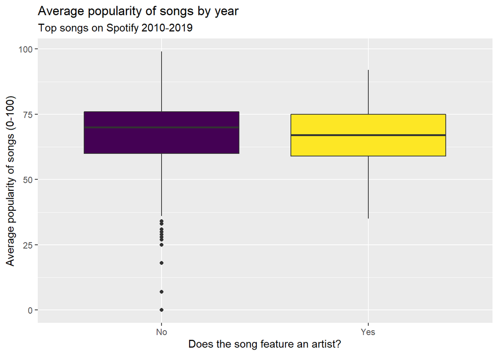

From this graph we see songs that do not feature an additional artist tend to be slightly more popular, with a higher median, maximum, and 25 and 75 percentiles. However, these songs are also less consistent as the whiskers stretch farther and there are a series of outliers with popularity scores far less than the minimum popularity of songs with features.

Since we are calculating means for our test, let’s take a look at how the summed average popularity of each type fares.

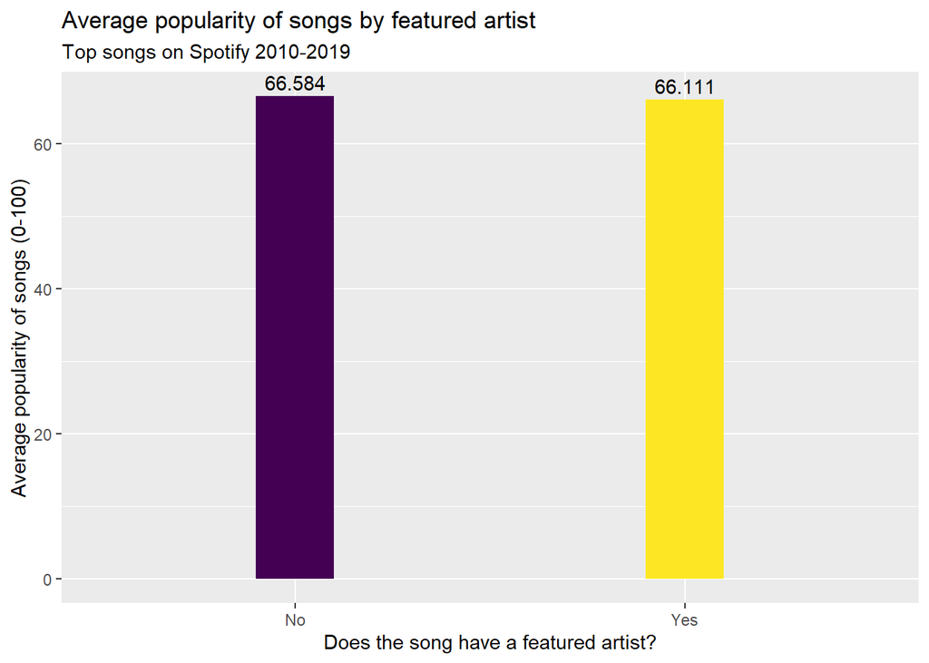

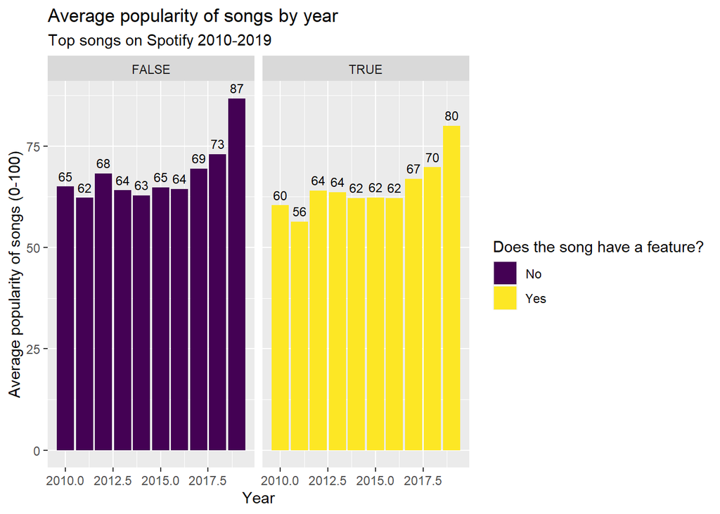

In each year, songs with a feature seem to be rated consistently a bit lower. However, overall there is hardly a difference in the average popularity of songs.

To see if the data agrees with these observations, we now calculate the test statistic from the formula below and obtain a p-value from its distribution.

$$z = \frac{x_1 - x_2}{\sqrt{\frac{\sigma^2_1}{n_1} + \frac{\sigma^2_2}{n_2}}}$$

```
## [1] "Determined p-value: 0.751682203993418"
```

The determined p-value is close to 1, far too large for any reasonable significance level. Therefore we do not reject the null hypothesis.

It is unlikely that having a featured artist has any bearing on a song’s popularity.

# Discussion

### Tying together the results

In none of the questions tested did an another variable have a significant linear relationship with the popularity of a song. Therefore, we do not believe that a song’s popularity is attributable to any one individual cause.

We have to acknowledge possible short-comings of this analysis. First, all the observed songs are all from billboard popular charts. For a more extensive analysis with less relative popularity, we might need to consider objectively unpopular songs. Additionally, some of the tests used assumed a binomial or normal distribution. The smaller size of this dataset may make the shape of the distribution less clear and the assumption weaker.

For further analysis or to alleviate these possible sources of error, there are new directions we could take our study. To expand the dataset and address the above concerns, we could consider older songs, less popular songs that aren’t on the billboard top charts, or another source besides Spotify since although the data is top songs in the world Spotify’s base is largely in the United States and may not represent ‘popularity’ wholly. In our analysis, we mostly considered an aggregate of popularity over the decade. It would be interesting to consider popularity trends in individual years in the decade, or in other decades if we expanded the dataset. Additionally, if we had binned international data we could explore popularity trends by region.

Before our analysis, we argued that while there are similarities between songs and artists that are popular at any one time, the popularity of a song is not influenced directly by any one variable. In Question 1, we found that none of the numeric metadata has a strong correlation with popularity. In Question 2, a large p-value indicated that the relevance of an artist does not dictate the popularity of their song. In Question 3, a small, significant p-value informed that pop artists (genre deemed ‘pop’) do remain on the billboard charts longer than non-pop artists. However, just being on the billboard charts does not guarantee a high popularity score. In Question 4, a large, insignificant p-value told that having a featured artist does not have a bearing on popularity score. All this considered, we believe our initial thesis statement holds.

# References

**Data:** [Top Spotify songs from 2010-2019 - BY YEAR from Kaggle](https://www.kaggle.com/leonardopena/top-spotify-songs-from-20102019-by-year).